# AREE Proteomics Workflow Report

TIMMINS2014_OA_GILL / mech_stress_vs_none_at_400

## Run summary

- **Study**: TIMMINS2014_OA_GILL
- **Comparison**: mech_stress_vs_none_at_400
- **Mode**: raw_reanalysis
- **Workflow version**: 0.1.0-scaffold
- **Date generated**: 2026-10-17T12:04:07.424967-07:00
- **Provenance level**: infra-level (see docs/design.md section 4; distinct from per-row evidence-level provenance)

No warnings recorded for this run.

## QC metrics

| metric | value |
| --- | --- |
| n_proteins | 618 |
| mean_missingness_percent | 4.89482200647249 |

limma on 4 control vs 4 treatment samples: 618 of 1616 proteins tested (detected in at least 3 samples per arm), 0 at padj < 0.05. Not tested: detected_too_rarely_in_both_arms 614; detected_too_rarely_in_control 96; detected_too_rarely_in_treatment 111; not_detected 177.

## Missingness distribution

Per-protein `missingness_percent` from the standardized evidence-ready table. Values of `NA` indicate the source study/mode did not report missingness (this is left explicit, not imputed as zero, per docs/design.md section 4).

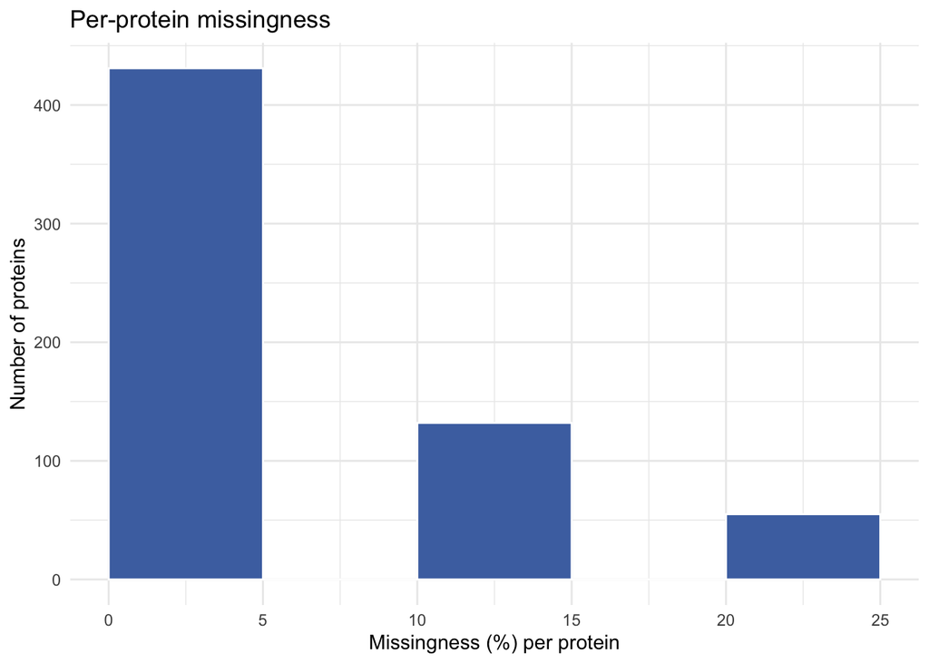

## Volcano plot

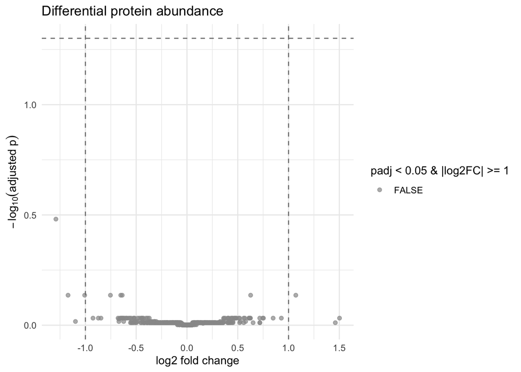

## Top differentially abundant proteins

| protein_accession | gene_symbol | log2FC | lfcSE | pvalue | padj | missingness_percent | analysis_method |
| --- | --- | --- | --- | --- | --- | --- | --- |
| CGI_10007607 | CGI_10007607 | -1.2904219 | 0.2459150 | 0.0005345 | 0.3303076 | 25.0 | spectral_count_limma_moderated_t |
| CGI_10004771 | LOC105345764 | -0.7535366 | 0.2401195 | 0.0094644 | 0.7311220 | 0.0 | spectral_count_limma_moderated_t |
| CGI_10006479 | LOC105334726 | -1.0071436 | 0.2900095 | 0.0070483 | 0.7311220 | 25.0 | spectral_count_limma_moderated_t |
| CGI_10011029 | CGI_10011029 | -0.6518919 | 0.2052742 | 0.0088526 | 0.7311220 | 0.0 | spectral_count_limma_moderated_t |
| CGI_10011652 | LOC105346349 | 0.6267351 | 0.1952097 | 0.0083205 | 0.7311220 | 0.0 | spectral_count_limma_moderated_t |
| CGI_10017017 | LOC105338423 | 1.0716371 | 0.2741300 | 0.0029312 | 0.7311220 | 12.5 | spectral_count_limma_moderated_t |
| CGI_10023351 | CGI_10023351 | -1.1708763 | 0.3408296 | 0.0064045 | 0.7311220 | 12.5 | spectral_count_limma_moderated_t |
| CGI_10026072 | LOC105341116 | -0.6374100 | 0.1972690 | 0.0090324 | 0.7311220 | 12.5 | spectral_count_limma_moderated_t |
| CGI_10000041 | CGI_10000041 | -0.8726494 | 0.3346944 | 0.0262129 | 0.9288146 | 12.5 | spectral_count_limma_moderated_t |
| CGI_10001170 | LOC105338756 | 0.8484072 | 0.3240490 | 0.0239487 | 0.9288146 | 0.0 | spectral_count_limma_moderated_t |
| CGI_10001348 | LOC105324454 | -0.4424676 | 0.2295431 | 0.0801744 | 0.9288146 | 0.0 | spectral_count_limma_moderated_t |
| CGI_10001407 | CGI_10001407 | -0.6583849 | 0.3478103 | 0.0910016 | 0.9288146 | 25.0 | spectral_count_limma_moderated_t |
| CGI_10001554 | CGI_10001554 | 0.5185837 | 0.2110239 | 0.0338802 | 0.9288146 | 12.5 | spectral_count_limma_moderated_t |
| CGI_10001653 | LOC105329634 | 0.4858710 | 0.2323747 | 0.0606051 | 0.9288146 | 0.0 | spectral_count_limma_moderated_t |
| CGI_10004590 | LOC105332564 | 0.5694234 | 0.2287885 | 0.0321085 | 0.9288146 | 12.5 | spectral_count_limma_moderated_t |
| CGI_10006015 | LOC105334846 | -0.5982962 | 0.2844700 | 0.0648687 | 0.9288146 | 25.0 | spectral_count_limma_moderated_t |
| CGI_10006016 | LOC105334847 | -0.4015073 | 0.1987743 | 0.0684862 | 0.9288146 | 0.0 | spectral_count_limma_moderated_t |
| CGI_10006482 | CGI_10006482 | 0.7529408 | 0.3945043 | 0.0854813 | 0.9288146 | 12.5 | spectral_count_limma_moderated_t |
| CGI_10006796 | LOC105321203 | 0.9293105 | 0.3837520 | 0.0339558 | 0.9288146 | 0.0 | spectral_count_limma_moderated_t |
| CGI_10007212 | LOC105333001 | -0.6451226 | 0.2245130 | 0.0151810 | 0.9288146 | 0.0 | spectral_count_limma_moderated_t |

## Reproducibility

```
List of 16
 $ workflow_name                 : chr "aree/workflows/proteomics"
 $ workflow_version              : chr "0.1.0-scaffold"
 $ mode                          : chr "raw_reanalysis"
 $ study_id                      : chr "TIMMINS2014_OA_GILL"
 $ comparison_id                 : chr "mech_stress_vs_none_at_400"
 $ date_generated                : chr "2026-10-17T12:04:07.424967-07:00"
 $ generated_by                  : chr "automated:aree-proteomics-workflow@0.1.0-scaffold"
 $ provenance_level              : chr "infra-level (see docs/design.md section 4; distinct from per-row evidence-level provenance)"
 $ inputs                        :List of 2
 $ parameters                    :List of 2
 $ software_versions             :List of 7
 $ software_versions_not_captured:List of 1
 $ container_engine              : NULL
 $ qc_metrics                    :List of 3
 $ missingness_summary           :List of 7
 $ warnings                      : list()
```

This report was generated from TIMMINS2014_OA_GILL_mech_stress_vs_none_at_400_protein_abundance_standardized.tsv and TIMMINS2014_OA_GILL_mech_stress_vs_none_at_400_manifest.json by the AREE proteomics workflow scaffold. It is intended to accompany, not replace, the standardized TSV as the machine-readable artifact consumed by `aree harmonize`.